# Mendelian Randomization Analysis

Dr. Shea Andrews

2018-10-12

## Instrumental Variables

**SNP Inclusion:** SNPS associated with at a p-value threshold of p < 5e-8 were included in this analysis.

**LD Clumping:** For standard two sample MR it is important to ensure that the instruments for the exposure are independent. LD clumping was performed in PLINK using the EUR samples from the 1000 Genomes Project to estimate LD between SNPs, and, amongst SNPs that have an LD above a given threshold, retain only the SNP with the lowest p-value. A clumping window of 250kb, r2 of 0.1 and significance level of 1 was used for the index and secondary SNPs.

**Proxy SNPs:** Where SNPs were not available in the outcome GWAS, the EUR thousand genomes was queried to identify potential proxy SNPs that are in linkage disequilibrium (r2 > 0.8) of the missing SNP.

### Exposure: AAOS

*Alzheimer’s Age of Onset Surivial* [Huang et al 2017](https://doi.org/10.1038/nn.4587): A GWAS of age of onset in LOAD was conducted in 14,406 AD case samples and 25,849 control samples from the IGAP using Cox proportional hazard regressions. Participants were of European ancestry, in cases the the average AAO was 74.8 and 61.7% were women, in controls the average AAE was 79.0 and 59.6% were women.

**Table 1:** Independent SNPs associated with AAOS

| SNP | CHR | POS | Effect_allele | Non_Effect_allele | EAF | Beta | SE | P | r2 | N |
| --- | --- | --- | --- | --- | --- | --- | --- | --- | --- | --- |
| rs6431219 | 2 | 127862133 | T | C | 0.4163 | 0.0774 | 0.0124 | 3.897e-10 | 0.002911441 | 40255 |
| rs13032148 | 2 | 127865100 | A | G | 0.3293 | 0.0820 | 0.0144 | 1.125e-08 | 0.002970146 | 40255 |
| rs7930318 | 11 | 60033371 | T | C | 0.5996 | 0.0750 | 0.0125 | 2.245e-09 | 0.002700898 | 40255 |
| rs567075 | 11 | 85830157 | T | C | 0.3097 | -0.0900 | 0.0132 | 9.084e-12 | 0.003463332 | 40255 |
| rs2301274 | 19 | 45146402 | T | C | 0.7677 | 0.0899 | 0.0147 | 9.572e-10 | 0.002882638 | 40255 |
| rs2965101 | 19 | 45237812 | T | C | 0.6815 | 0.1075 | 0.0135 | 1.432e-15 | 0.005016747 | 40255 |
| rs8103315 | 19 | 45254168 | A | C | 0.1479 | 0.1652 | 0.0262 | 3.074e-10 | 0.006878739 | 40255 |
| rs28399657 | 19 | 45318351 | A | G | 0.9772 | 0.3195 | 0.0574 | 2.603e-08 | 0.004548729 | 40255 |
| rs28399664 | 19 | 45324756 | C | G | 0.9593 | -0.7349 | 0.0805 | 6.888e-20 | 0.042173082 | 40255 |
| rs10412413 | 19 | 45327309 | T | C | 0.3551 | 0.1896 | 0.0125 | 8.083e-52 | 0.016464544 | 40255 |

[output cut: 10 more lines]

### Outcome: HDL Cholesterol

*HDL Cholesterol* [Willer et al Nat Genet 2013](https://www.nature.com/articles/ng.2797): To identify new loci and refine known loci influencing these lipids, we examined 188,577 individuals using genome-wide and custom genotyping arrays. We identify and annotate 157 loci associated with lipid levels at P < 5 108, including 62 loci not previously associated with lipid levels in humans.

**Table 2:** SNPs associated with AAOS avaliable in HDL Cholesterol

| SNP | CHR | POS | Effect_allele | Non_Effect_allele | EAF | Beta | SE | P | r2 | N |
| --- | --- | --- | --- | --- | --- | --- | --- | --- | --- | --- |
| rs6431219 | NA | NA | NA | NA | NA | NA | NA | NA | NA | NA |
| rs13032148 | NA | NA | NA | NA | NA | NA | NA | NA | NA | NA |
| rs7930318 | NA | NA | NA | NA | NA | NA | NA | NA | NA | NA |
| rs567075 | 11 | 85830157 | T | C | 0.33510 | 0.0002 | 0.0050 | 7.740e-01 | 1.782464e-08 | 94311.00 |
| rs2301274 | NA | NA | NA | NA | NA | NA | NA | NA | NA | NA |
| rs2965101 | 19 | 45237812 | C | T | 0.34700 | 0.0130 | 0.0037 | 5.482e-04 | 7.658776e-05 | 184801.00 |
| rs8103315 | 19 | 45254168 | C | A | 0.86410 | 0.0117 | 0.0053 | 5.092e-02 | 3.215031e-05 | 156397.04 |
| rs28399657 | NA | NA | NA | NA | NA | NA | NA | NA | NA | NA |
| rs28399664 | NA | NA | NA | NA | NA | NA | NA | NA | NA | NA |
| rs10412413 | NA | NA | NA | NA | NA | NA | NA | NA | NA | NA |

[output cut: 10 more lines]

**Table 3:** Proxy SNPs for HDL Cholesterol

| query_snp_rsid | rsID | ld.r2 | Dprime | ref.proxy | alt.proxy | CHR | POS | Effect_allele.proxy | Non_Effect_allele.proxy | EAF | Beta | SE | P | r2 | N | ref | alt | Effect_allele | Non_Effect_allele |
| --- | --- | --- | --- | --- | --- | --- | --- | --- | --- | --- | --- | --- | --- | --- | --- | --- | --- | --- | --- |
| rs10412413 | rs10402271 | 1.00 | 1.00 | T | G | 19 | 45329214 | T | G | 0.65960 | 0.0205 | 0.0035 | 6.148e-09 | 1.887156e-04 | 185466.0 | C | T | C | T |
| rs11665676 | rs11667640 | 0.84 | 1.00 | C | T | 19 | 45379791 | T | C | 0.06069 | 0.0110 | 0.0069 | 2.183e-01 | 1.379563e-05 | 180175.5 | C | T | T | C |
| rs13032148 | NA | NA | NA | NA | NA | NA | NA | NA | NA | NA | NA | NA | NA | NA | NA | NA | NA | NA | NA |
| rs157595 | rs439401 | 0.80 | 0.94 | T | C | 19 | 45414451 | T | C | 0.37990 | 0.0273 | 0.0040 | 2.328e-10 | 3.511449e-04 | 162080.0 | A | G | A | G |
| rs16979586 | rs7257610 | 1.00 | 1.00 | G | A | 19 | 45490428 | A | G | 0.04617 | 0.0280 | 0.0102 | 3.228e-02 | 6.905210e-05 | 162565.3 | A | G | G | A |
| rs2004357 | rs1114831 | 1.00 | 1.00 | C | A | 19 | 45636319 | A | C | 0.10550 | 0.0046 | 0.0081 | 4.639e-01 | 3.993728e-06 | 92820.0 | G | A | A | G |
| rs2301274 | rs7255066 | 0.87 | 0.99 | T | C | 19 | 45146103 | C | T | 0.26390 | 0.0155 | 0.0059 | 3.060e-02 | 9.334039e-05 | 92820.0 | T | C | C | T |
| rs28399657 | NA | NA | NA | NA | NA | NA | NA | NA | NA | NA | NA | NA | NA | NA | NA | NA | NA | NA | NA |
| rs28399664 | NA | NA | NA | NA | NA | NA | NA | NA | NA | NA | NA | NA | NA | NA | NA | NA | NA | NA | NA |
| rs41290120 | NA | NA | NA | NA | NA | NA | NA | NA | NA | NA | NA | NA | NA | NA | NA | NA | NA | NA | NA |

[output cut: 3 more lines]

## Data harmonization

Harmonize the exposure and outcome datasets so that the effect of a SNP on the exposure and the effect of that SNP on the outcome correspond to the same allele. The harmonise_data function from the TwoSampleMR package can be used to perform the harmonization step, by default it try’s to infer the forward strand alleles using allele frequency information. EAF were not availbe in the IGAP summary statisitics, as such the allele frequencies reported in the AAOS anaylsis were used.

**Table 4:** Harmonized AAOS and HDL Cholesterol datasets

| SNP | effect_allele.exposure | other_allele.exposure | effect_allele.outcome | other_allele.outcome | beta.exposure | beta.outcome | eaf.exposure | eaf.outcome | remove | palindromic | ambiguous | id.outcome | se.outcome | pval.outcome | outcome | mr_keep.outcome | pval_origin.outcome | se.exposure | pval.exposure | exposure | mr_keep.exposure | pval_origin.exposure | id.exposure | action | mr_keep | samplesize.outcome | mrpresso_RSSobs | mrpresso_pval | mrpresso_keep |
| --- | --- | --- | --- | --- | --- | --- | --- | --- | --- | --- | --- | --- | --- | --- | --- | --- | --- | --- | --- | --- | --- | --- | --- | --- | --- | --- | --- | --- | --- |
| rs10412413 | T | C | T | C | 0.1896 | -0.0205 | 0.3551 | 0.34040 | FALSE | FALSE | FALSE | rpg3mR | 0.0035 | 6.148e-09 | hdl | TRUE | reported | 0.0125 | 8.083e-52 | aaos | TRUE | reported | qlijUH | 2 | TRUE | NA | 2.187375e-05 | 1 | TRUE |
| rs11665676 | T | C | T | C | -0.2168 | 0.0110 | 0.0456 | 0.06069 | FALSE | FALSE | FALSE | rpg3mR | 0.0069 | 2.183e-01 | hdl | TRUE | reported | 0.0323 | 2.049e-11 | aaos | TRUE | reported | qlijUH | 2 | TRUE | NA | 6.366260e-05 | 1 | TRUE |
| rs12610605 | A | G | A | G | -0.1229 | -0.0096 | 0.1600 | 0.14510 | FALSE | FALSE | FALSE | rpg3mR | 0.0045 | 1.140e-01 | hdl | TRUE | reported | 0.0171 | 6.842e-13 | aaos | TRUE | reported | qlijUH | 2 | TRUE | NA | 4.315300e-04 | <0.014 | FALSE |
| rs157595 | A | G | A | G | -0.2787 | 0.0273 | 0.3711 | 0.37990 | FALSE | FALSE | FALSE | rpg3mR | 0.0040 | 2.328e-10 | hdl | TRUE | reported | 0.0308 | 1.304e-19 | aaos | TRUE | reported | qlijUH | 2 | TRUE | NA | 1.612440e-05 | 1 | TRUE |
| rs16979586 | A | G | A | G | -0.2032 | -0.0280 | 0.9504 | 0.95383 | FALSE | FALSE | FALSE | rpg3mR | 0.0102 | 3.228e-02 | hdl | TRUE | reported | 0.0268 | 3.396e-14 | aaos | TRUE | reported | qlijUH | 2 | TRUE | NA | 2.134435e-03 | <0.014 | FALSE |
| rs2004357 | A | G | A | G | 0.1825 | 0.0046 | 0.0921 | 0.10550 | FALSE | FALSE | FALSE | rpg3mR | 0.0081 | 4.639e-01 | hdl | TRUE | reported | 0.0222 | 1.795e-16 | aaos | TRUE | reported | qlijUH | 2 | TRUE | NA | 4.294169e-04 | 0.182 | TRUE |
| rs2075650 | A | G | A | G | -0.5502 | 0.0554 | 0.7803 | 0.87340 | FALSE | FALSE | FALSE | rpg3mR | 0.0051 | 9.716e-26 | hdl | TRUE | reported | 0.0223 | 5.980e-134 | aaos | TRUE | reported | qlijUH | 2 | TRUE | NA | 2.015121e-04 | 0.994 | TRUE |
| rs2301274 | T | C | T | C | 0.0899 | -0.0155 | 0.7677 | 0.73610 | FALSE | FALSE | FALSE | rpg3mR | 0.0059 | 3.060e-02 | hdl | TRUE | reported | 0.0147 | 9.572e-10 | aaos | TRUE | reported | qlijUH | 2 | TRUE | NA | 6.116911e-05 | 1 | TRUE |
| rs2965101 | T | C | T | C | 0.1075 | -0.0130 | 0.6815 | 0.65300 | FALSE | FALSE | FALSE | rpg3mR | 0.0037 | 5.482e-04 | hdl | TRUE | reported | 0.0135 | 1.432e-15 | aaos | TRUE | reported | qlijUH | 2 | TRUE | NA | 1.488839e-05 | 1 | TRUE |
| rs567075 | T | C | T | C | -0.0900 | 0.0002 | 0.3097 | 0.33510 | FALSE | FALSE | FALSE | rpg3mR | 0.0050 | 7.740e-01 | hdl | TRUE | reported | 0.0132 | 9.084e-12 | aaos | TRUE | reported | qlijUH | 2 | TRUE | NA | 5.850618e-05 | 1 | TRUE |

[output cut: 4 more lines]

## MR Results

To obtain an overall estimate of causal effect, the SNP-exposure and SNP-outcome coefficients were combined in 1) a fixed-effects meta-analysis using an inverse-variance weighted approach (IVW); 2) a Weighted Median approach; 3) Weighted Mode approach and 4) Egger Regression.

[**IVW**](https://doi.org/10.1002/gepi.21758) is equivalent to a weighted regression of the SNP-outcome coefficients on the SNP-exposure coefficients with the intercept constrained to zero. This method assumes that all variants are valid instrumental variables based on the Mendelian randomization assumptions. The causal estimate of the IVW analysis expresses the causal increase in the outcome (or log odds of the outcome for a binary outcome) per unit change in the exposure. [**Weighted median MR**](https://doi.org/10.1002/gepi.21965) allows for 50% of the instrumental variables to be invalid. [**MR-Egger regression**](https://doi.org/10.1093/ije/dyw220) allows all the instrumental variables to be subject to direct effects (i.e. horizontal pleiotropy), with the intercept representing bias in the causal estimate due to pleiotropy and the slope representing the causal estimate. [**Weighted Mode**](https://doi.org/10.1093/ije/dyx102) gives consistent estimates as the sample size increases if a plurality (or weighted plurality) of the genetic variants are valid instruments.

Table 5 presents the MR causal estimates of genetically predicted AAOS on HDL Cholesterol.

**Table 5** MR causaul estimates for AAOS on HDL Cholesterol

| id.exposure | id.outcome | outcome | exposure | method | nsnp | b | se | pval |
| --- | --- | --- | --- | --- | --- | --- | --- | --- |
| qlijUH | rpg3mR | hdl | aaos | Inverse variance weighted (fixed effects) | 14 | -0.08617548 | 0.006130470 | 6.986877e-45 |
| qlijUH | rpg3mR | hdl | aaos | Weighted median | 14 | -0.10019293 | 0.008462503 | 2.435164e-32 |
| qlijUH | rpg3mR | hdl | aaos | Weighted mode | 14 | -0.10189352 | 0.007731040 | 6.733492e-09 |
| qlijUH | rpg3mR | hdl | aaos | MR Egger | 14 | -0.12648784 | 0.027450168 | 6.026413e-04 |

Figure 1 illustrates the SNP-specific associations with AAOS versus the association in HDL Cholesterol and the corresponding MR estimates.

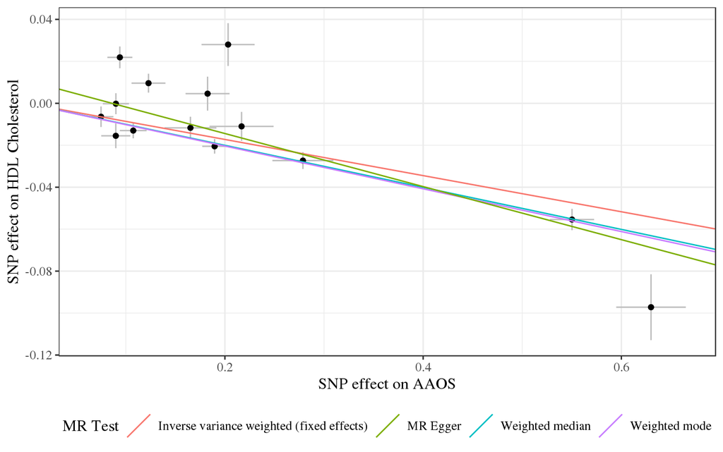

Fig. 1: Scatterplot of SNP effects for the association of the Exposure on the Outcome

## Pleiotropy

Figure 2 shows a funnel plot displaying the MR estimates of individual genetic variants against their precession. Aysmmetry in the funnel plot may arrise due to some genetic variants having unusally strong effects on the outcome, which is indicative of directional pleiotropy.

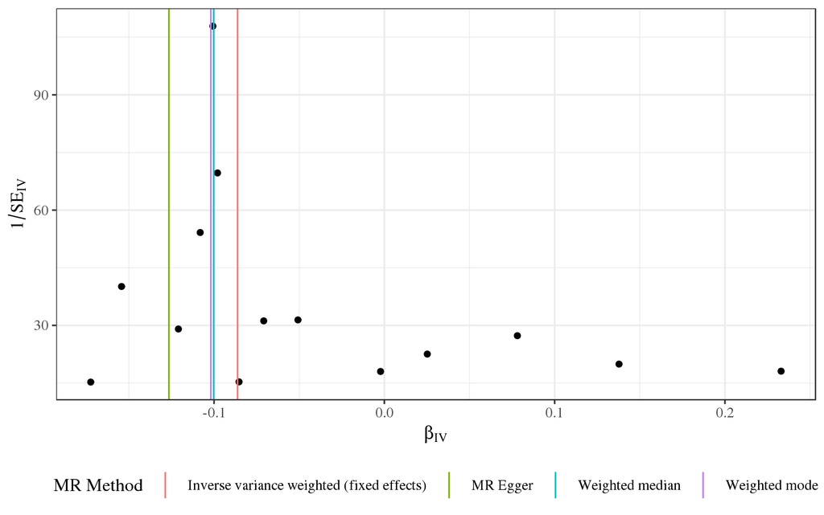

Fig. 2: Funnel plot of the MR causal estimates against their precession

A Cochrans Q heterogeneity test can be used to formaly assesse for the presence of heterogenity (Table 6).

**Table 6:** Heterogenity Tests

| id.exposure | id.outcome | outcome | exposure | method | Q | Q_df | Q_pval |
| --- | --- | --- | --- | --- | --- | --- | --- |
| qlijUH | rpg3mR | hdl | aaos | MR Egger | 77.56218 | 12 | 1.201350e-11 |
| qlijUH | rpg3mR | hdl | aaos | Inverse variance weighted | 98.13378 | 13 | 3.811307e-15 |

The intercept of the MR-Regression model captures the average pleitropic affect across all genetic variants (Table 7).

**Table 7:** MR Egger test for directional pleitropy

| id.exposure | id.outcome | outcome | exposure | egger_intercept | se | pval |
| --- | --- | --- | --- | --- | --- | --- |
| qlijUH | rpg3mR | hdl | aaos | 0.010892 | 0.006105315 | 0.09970628 |

Pleiotropy was also assesed using Mendelian Randomization Pleiotropy RESidual Sum and Outlier [(MR-PRESSO)](https://doi.org/10.1038/s41588-018-0099-7), that allows for the evlation of evaluation of horizontal pleiotropy in a standared MR model (Table 8). MR-PRESSO performs a global test for detection of horizontal pleiotropy and correction of pleiotropy via outlier removal (Table 9).

**Table 8:** MR-PRESSO Global Test for pleitropy

| id.exposure | id.outcome | outcome | exposure | n_outliers | RSSobs | pval |
| --- | --- | --- | --- | --- | --- | --- |
| qlijUH | rpg3mR | hdl | aaos | 4 | 108.2646 | <0.001 |

**Table 9:** MR Estimates after MR-PRESSO outlier removal

| id.exposure | id.outcome | outcome | exposure | method | nsnp | b | se | pval |
| --- | --- | --- | --- | --- | --- | --- | --- | --- |
| qlijUH | rpg3mR | hdl | aaos | Inverse variance weighted (fixed effects) | 10 | -0.0949326 | 0.006519291 | 4.914740e-48 |
| qlijUH | rpg3mR | hdl | aaos | Weighted median | 10 | -0.1001601 | 0.008384962 | 6.878358e-33 |
| qlijUH | rpg3mR | hdl | aaos | Weighted mode | 10 | -0.1012004 | 0.008472630 | 8.010596e-07 |
| qlijUH | rpg3mR | hdl | aaos | MR Egger | 10 | -0.1017972 | 0.016101603 | 2.272969e-04 |

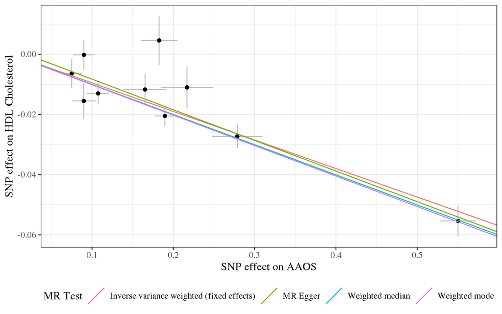

Fig. 3: Scatterplot of SNP effects for the association of the Exposure on the Outcome after outlier removal